# CSE5DEV_ASSIGNMENT_2

Angad Dharmashri Kadam

2022-09-24

```r
library(ggplot2)
student_df=read.csv("C:\\Users\\Angat\\Downloads\\Datasets-20220912\\Studentmarks.csv",header = TRUE)
student_df
```

```
##    StudentID Studentname        dob X2020 X2021 X2022
## 1          1        Anna 12/12/1998    75    78    85
## 2          2       James 10/08/1999    65    74    52
## 3          3        Mary 21/08/1998    56    68    90
## 4          4      Antony 02/05/1999    78    65    85
## 5          5       Jacob 22/07/1998    85    78    65
## 6          6     Angelin 11/05/1998    65    68    70
## 7          7      Kellie 19/04/1999    78    52    88
## 8          8       Jesse 27/06/1998    77    72    75
## 9          9        John 15/10/1998    90    87    88
## 10        10     Therese 06/11/1998    95    85    75
```

# TASK_1

#### **a. Calculate the age of the students and add that as a new column age1**

```r
#Dividing by 365 to convert the days into the years returned by the difference of dates below
student_df$age_1<-as.integer((Sys.Date()-as.Date(student_df$dob,format = "%d/%m/%Y"))/365)
student_df
```

```
##    StudentID Studentname        dob X2020 X2021 X2022 age_1
## 1          1        Anna 12/12/1998    75    78    85    23
## 2          2       James 10/08/1999    65    74    52    23
## 3          3        Mary 21/08/1998    56    68    90    24
## 4          4      Antony 02/05/1999    78    65    85    23
## 5          5       Jacob 22/07/1998    85    78    65    24
## 6          6     Angelin 11/05/1998    65    68    70    24
## 7          7      Kellie 19/04/1999    78    52    88    23
## 8          8       Jesse 27/06/1998    77    72    75    24
## 9          9        John 15/10/1998    90    87    88    23
## 10        10     Therese 06/11/1998    95    85    75    23
```

#### **b. Split the dob column into date month and year and then calculate the age based on the year column only and add that as a new column age2**

```r
#Splitting the Date into date,month and year
x<-as.Date(student_df$dob,format = "%d/%m/%Y")
student_df$date<-as.numeric(strftime(x,format="%d"))
student_df$month<-as.numeric(strftime(x,format="%m"))
student_df$year<-as.numeric(strftime(x,format="%Y"))
student_df$age_2<-2022-student_df$year
```

#### **c. Create a scatter plot for Studentname versus Marks of all three years**

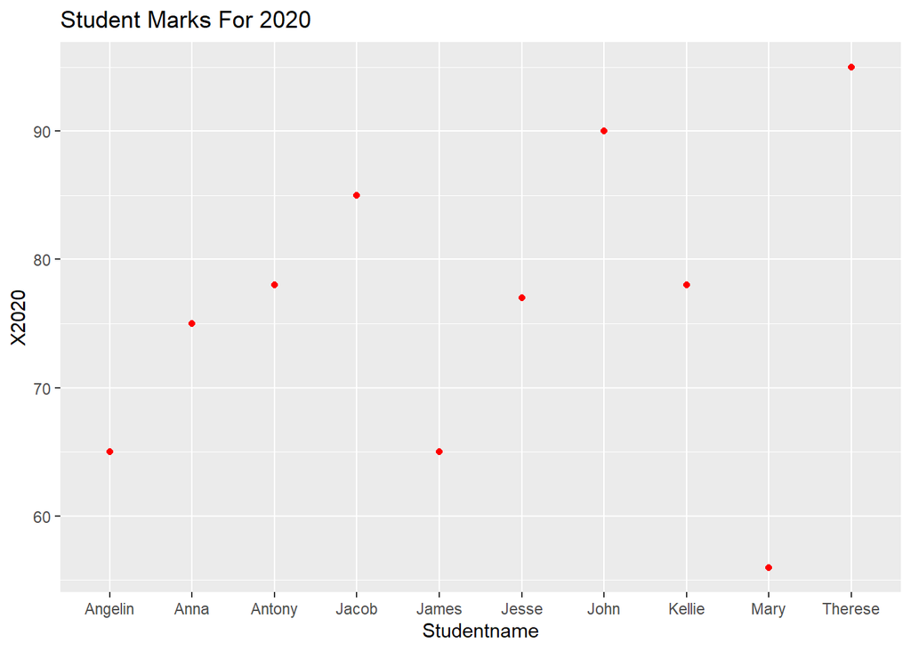

```r
ggplot(data=student_df,aes(x=Studentname,y=X2020))+geom_point(color="red")+labs(title = "Student Marks For 2020")
```

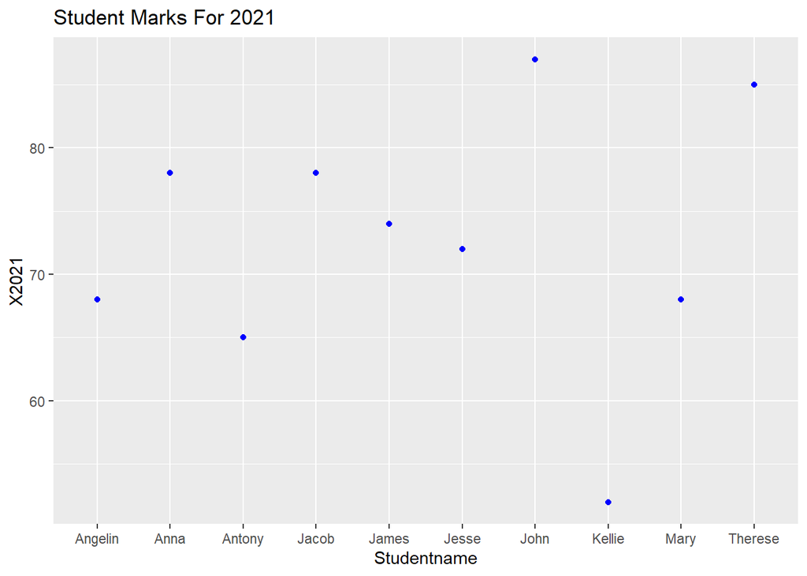

```r
ggplot(data=student_df,aes(x=Studentname,y=X2021))+geom_point(color="blue")+labs(title = "Student Marks For 2021")
```

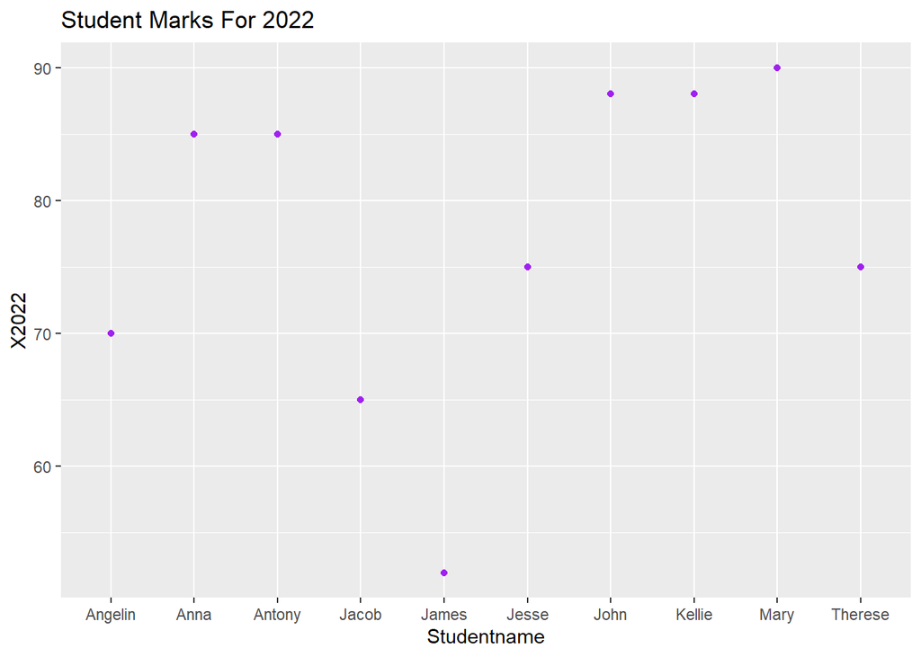

```r
ggplot(data=student_df,aes(x=Studentname,y=X2022))+geom_point(color="purple")+labs(title = "Student Marks For 2022")
```

#### **d. Calculate the total marks of all students and filter the who got at least 200 marks in total and create a bar chart for students vs totalmarks in the descending order of their marks.**

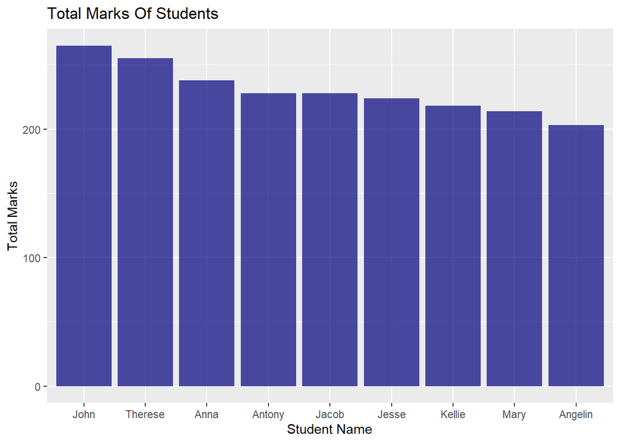

```r
student_df$total_marks<-student_df$X2020+student_df$X2021+student_df$X2022
top200<-student_df[student_df["total_marks"]>200,]
ggplot(data = top200,aes(x=reorder(Studentname,-total_marks),y=total_marks))+geom_bar(stat = "identity",fill="navy",alpha=0.7)+xlab("Student Name")+ylab("Total Marks")+labs(title = "Total Marks Of Students")
```

# TASK_2

#### **a. Handle missing values: Remove or impute all missing values? Support the method you choose (remove or impute) with appropriate arguments. You need to show the step by step process.**

```r
movie_df=read.csv("C:\\Users\\Angat\\Downloads\\Datasets-20220912\\Movies.csv",header = TRUE)
```

##### *Replacing all “” with NA*

```r
#Replacing all "" with NA
for (i in 1:ncol(movie_df)) {
movie_df[which(movie_df[,i]==""),i]<-NA
}
```

##### *Checking the missing values per column*

```r
#Checking the missing values per column
(colSums(is.na(movie_df))/nrow(movie_df))*100
```

```
##                     Color                  Director                   Reviews
##                0.05140067                0.00000000                0.02570033
##                  Duration   Director_facebook_likes    Actor_3_facebook_likes
##                0.02570033                0.00000000                0.25700334
##              Actor_2_name    Actor_1_facebook_likes                     Gross
##                0.12850167                0.07710100                0.00000000
##                     Genre              Actor_1_name                     Title
##                0.00000000                0.07710100                0.00000000
##                     Votes Cast_total_facebook_likes              Actor_3_name
##                0.00000000                0.00000000                0.25700334
##      Facenumber_in_poster             Plot_keywords           Movie_imdb_link
##                0.15420200                0.79671036                0.00000000
##                  Language            Content_rating                    Budget
##                0.00000000                1.90182472                0.00000000
##                      Year    Actor_2_facebook_likes                Imdb_score
##                0.00000000                0.12850167                0.00000000
##              Aspect_ratio      Movie_facebook_likes
##                1.92752506                0.00000000
```

##### *Since all the columns having missing values have less than 30% percent of missing values,so it would be appropriate to impute the missing values rather than removing them. If there were lot of missing values Like almost all rows are missing then definately we would have removed them because imputing them will create a bias in dataset.*

##### *Printing the columns having null values*

```r
#Printing the columns having null values
n<-c()
for (variable in names(movie_df)) {
  if(sum(is.na(movie_df[,variable]))>1){
    n<-append(n,variable)
  }
}
print(n)
```

```
##  [1] "Color"                  "Actor_3_facebook_likes" "Actor_2_name"
##  [4] "Actor_1_facebook_likes" "Actor_1_name"           "Actor_3_name"
##  [7] "Facenumber_in_poster"   "Plot_keywords"          "Content_rating"
## [10] "Actor_2_facebook_likes" "Aspect_ratio"
```

##### *Now lets seperate categorical columns and numerical columns*

```r
#Now lets seperate categorical columns and numerical columns
catCols<-c()
numCols<-c()
for(c in 1:ncol(movie_df)){
  if(class(movie_df[,c])=="character"){
catCols<-append(catCols,c)
  }
  else{
    numCols<-append(numCols,c)
  }
}
```

##### *Lets see the difference in mean and median for all columns,if majority of the columns have large difference in mean and median differences,we will impute NAs with median. Even with low difference median can work.*

```r
#Lets see the difference in mean and median for all columns,if majority of the columns have large difference in mean and median differences,we will impute NAs with median. Even with low difference median can work.
for(i in numCols){
print(paste("For %d",i,"The Mean and Median diff is %d",abs((mean(movie_df[,i],na.rm = TRUE)-median(movie_df[,i],na.rm = TRUE)))))
}
```

```
## [1] "For %d 3 The Mean and Median diff is %d 29.2347043701799"
## [1] "For %d 4 The Mean and Median diff is %d 3.89640102827764"
## [1] "For %d 5 The Mean and Median diff is %d 723.307375995888"
## [1] "For %d 6 The Mean and Median diff is %d 326.534913682041"
## [1] "For %d 8 The Mean and Median diff is %d 6584.67566872428"
## [1] "For %d 9 The Mean and Median diff is %d 23075595.2431252"
## [1] "For %d 13 The Mean and Median diff is %d 52168.4132613724"
## [1] "For %d 14 The Mean and Median diff is %d 8193.85813415574"
## [1] "For %d 16 The Mean and Median diff is %d 0.37992277992278"
## [1] "For %d 21 The Mean and Median diff is %d 21210278.2783346"
## [1] "For %d 22 The Mean and Median diff is %d 1.91852994088913"
## [1] "For %d 23 The Mean and Median diff is %d 1306.65697375193"
## [1] "For %d 24 The Mean and Median diff is %d 0.136494474428167"
## [1] "For %d 25 The Mean and Median diff is %d 0.240248951781971"
## [1] "For %d 26 The Mean and Median diff is %d 8929.15265998458"
```

##### *We Observe That majority of the Columns have huge difference so I guess its better to use median to replace NAS*

##### *Replacing Numerical columns with NA using median*

```r
#We Observe That majority of the Columns have huge difference so I guess its better to use median to replace NAS

#Replacing Numerical columns with NA using median
for (variable in numCols) {
movie_df[which(is.na(movie_df[variable])),variable]<-median(movie_df[,variable],na.rm = TRUE)
}
```

##### *For categorical columns we cannot use mean or median,we can only use mode.Before replacing the categorical data with mode,lets define a function to calculate a mode*

##### *Method to calculate Mode*

```r
#For categorical columns we cannot use mean or median,we can only use mode.Before replacing the categorical data with mode,lets define a function to calculate a mode

#Method to calculate Mode
Mode<-function(x) {
ux <- unique(x)
tab <- tabulate(match(x, ux))
ux[tab == max(tab)]
}
```

##### *Replacing NAS in categorical columns using Mode*

```r
#Replacing NAS in categorical columns using Mode
for (variable in catCols) {
movie_df[which(is.na(movie_df[variable])),variable]<-Mode(movie_df[,variable][1])
}
```

#### **b. Based on the Dataset, calculate “Profit” and determine the relationship between “Profit” and other variables (e.g. IMDB score). Hint: Profit = Gross - Budget. Use line plot or scatter plot to find the relationship. Present a summary of your findings.**

##### *We take relevant columns as Reviews,Duration,Director_fb_likes,Actors_likes,Total_fb_likes,Poster likes,Imbdbscore,movie likes for checking the relation with Profit.*

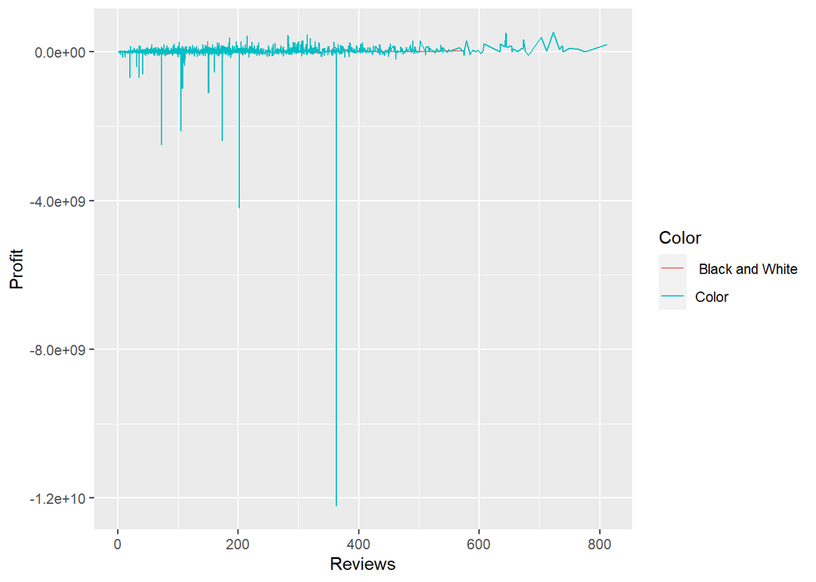

```r
movie_df["Profit"]<-movie_df["Gross"]-movie_df["Budget"]
# We take relevant columns as Reviews,Duration,Director_fb_likes,Actors_likes,Total_fb_likes,Poster likes,Imbdb score,movie likes for checking the relation with Profit.
relNumCols<-c("Reviews","Duration","Director_facebook_likes","Actor_3_facebook_likes","Actor_1_facebook_likes","Cast_total_facebook_likes","Facenumber_in_poster","Actor_2_facebook_likes"
,"Imdb_score","Movie_facebook_likes","Profit")

ggplot(data=movie_df,aes(x=Reviews,y=Profit,color=Color))+geom_line()
```

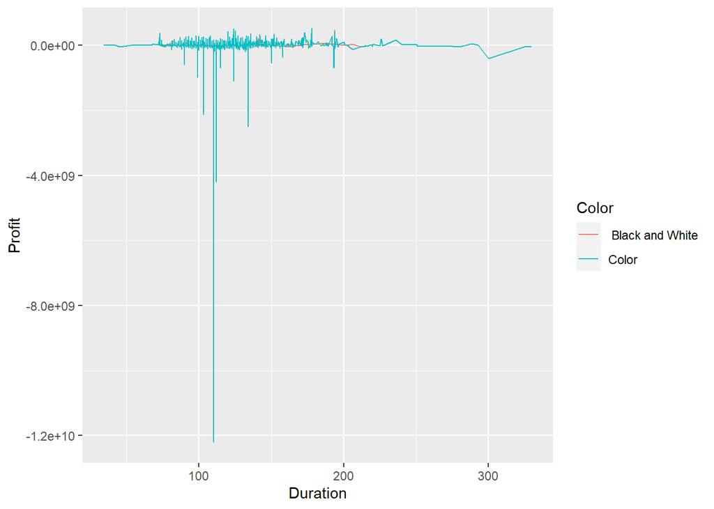

```r
ggplot(data=movie_df,aes(x=Duration,y=Profit,color=Color))+geom_line()
```

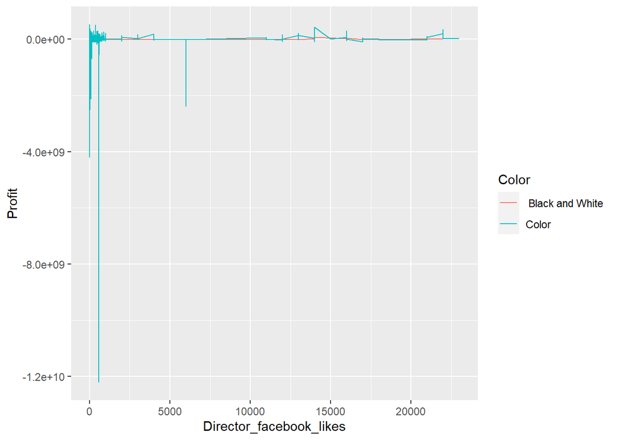

```r
ggplot(data=movie_df,aes(x=Director_facebook_likes,y=Profit,color=Color))+geom_line()
```

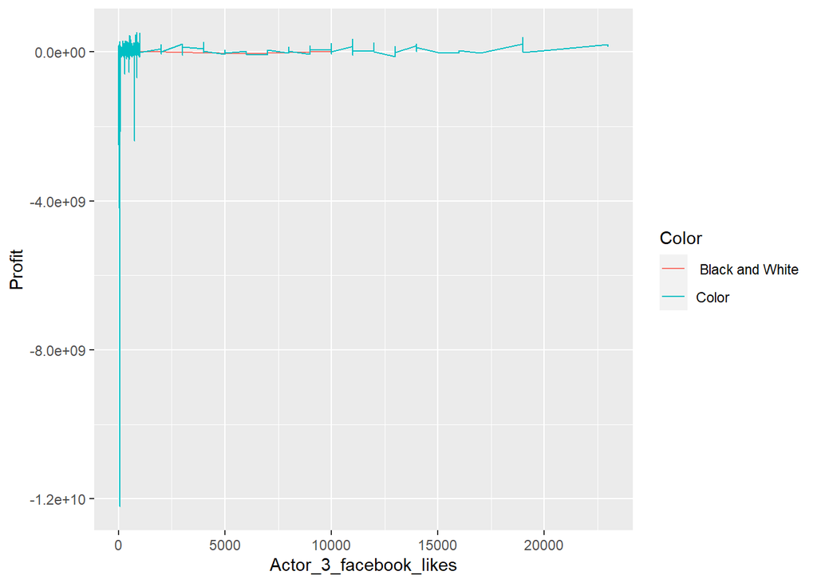

```r
ggplot(data=movie_df,aes(x=Actor_3_facebook_likes,y=Profit,color=Color))+geom_line()
```

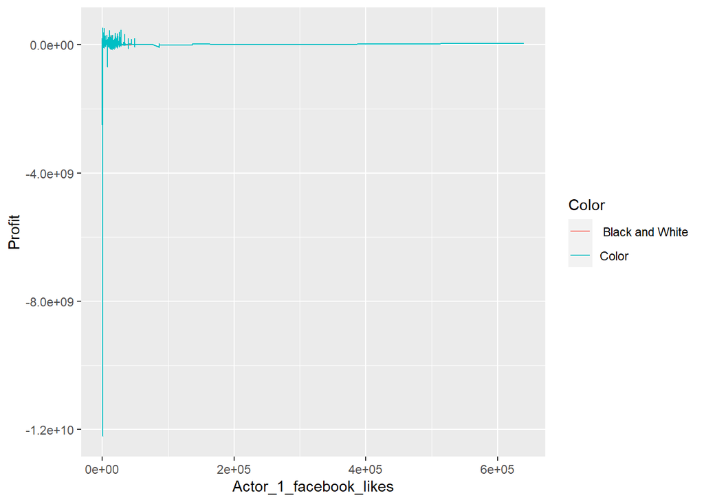

```r
ggplot(data=movie_df,aes(x=Actor_1_facebook_likes,y=Profit,color=Color))+geom_line()
```

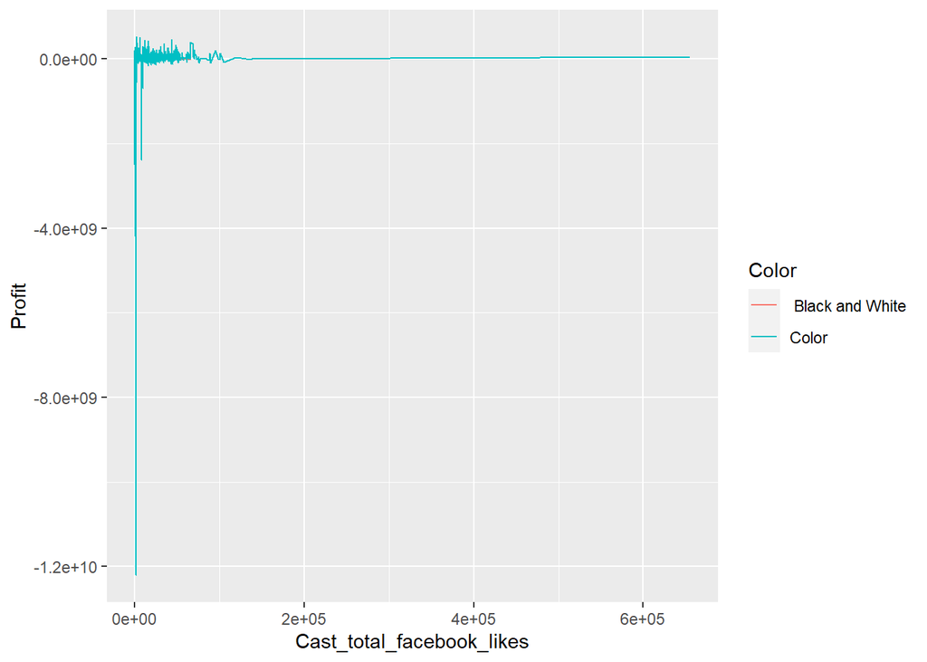

```r
ggplot(data=movie_df,aes(x=Cast_total_facebook_likes,y=Profit,color=Color))+geom_line()
```

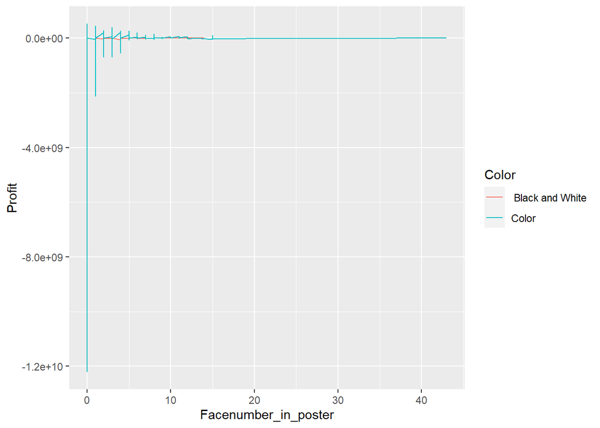

```r
ggplot(data=movie_df,aes(x=Facenumber_in_poster,y=Profit,color=Color))+geom_line()
```

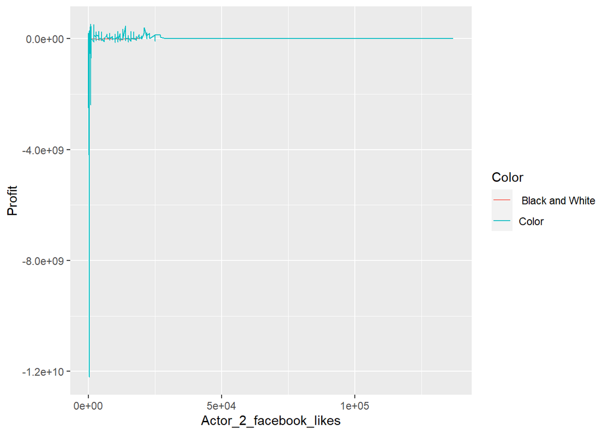

```r
ggplot(data=movie_df,aes(x=Actor_2_facebook_likes,y=Profit,color=Color))+geom_line()
```

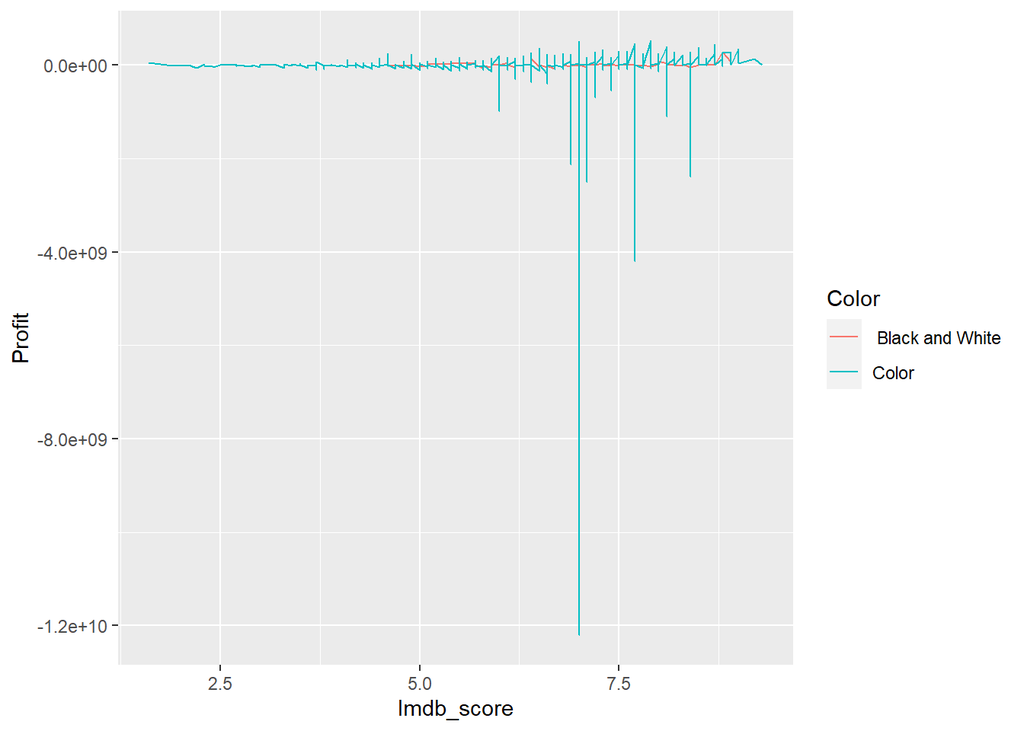

```r
ggplot(data=movie_df,aes(x=Imdb_score,y=Profit,color=Color))+geom_line()
```

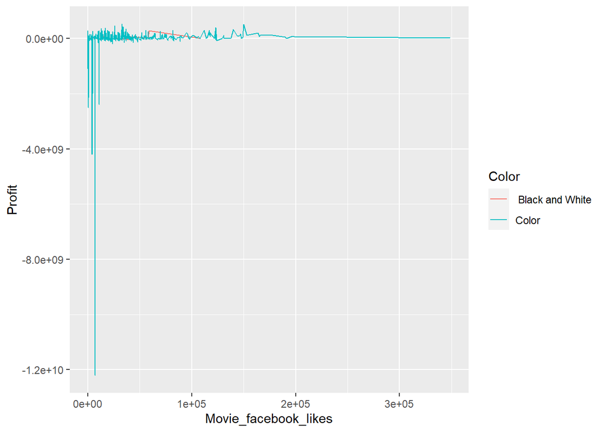

```r
ggplot(data=movie_df,aes(x=Movie_facebook_likes,y=Profit,color=Color))+geom_line()
```

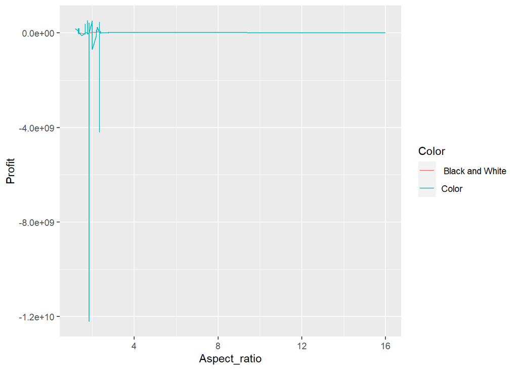

```r
ggplot(data=movie_df,aes(x=Aspect_ratio,y=Profit,color=Color))+geom_line()
```

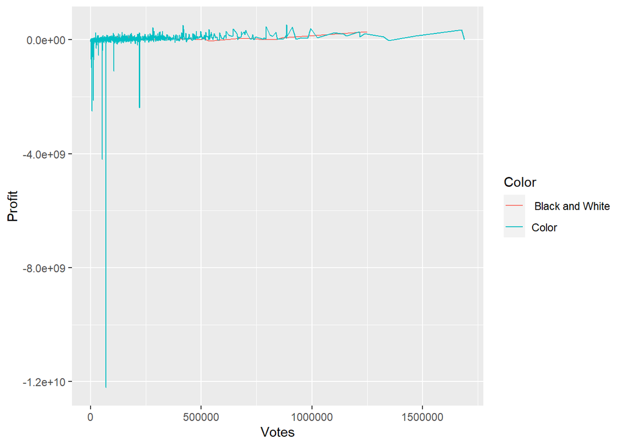

```r
ggplot(data=movie_df,aes(x=Votes,y=Profit,color=Color))+geom_line()
```

```r
# From Above line graphs we observe that there is no relationship between the variables compared with Profit Column. It maybe that It depends on the choices of people and based on that the movie might be making the profit.
```

##### *From Above line graphs we observe that there is no relationship between the variables compared with Profit Column. It maybe that It depends on the choices of people and based on that the movie might be making the profit.*

#### **c. Calculate the correlation between the relevant variable(s) used in the Dataset. Present a summary of your findings**

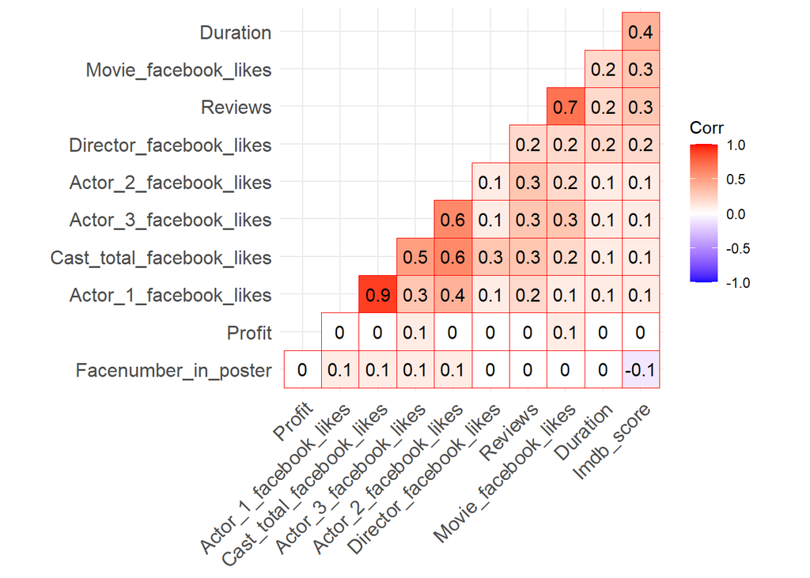

```r
library(ggcorrplot)
cors<-round(cor(movie_df[,relNumCols]),1)
ggcorrplot(cors, hc.order =TRUE, type ="lower",outline.color ="red",lab = TRUE)+scale_colour_brewer(type = "seq", palette = "Spectral")
```

```r
# 1.Actor_1_likes and casted_total FB likes are correlated.
# 2.Actor_2_likes and Actor_3_likes are correlated.
# 3.Actor_2_likes and casted_total FB likes are correlated.
# 4. Reviews and Movie_facebook_likes are correlated
```

- *Actor_1_likes and casted_total FB likes are correlated.*
- *Actor_2_likes and Actor_3_likes are correlated.*
- *Actor_2_likes and casted_total FB likes are correlated.*
- *Reviews and Movie_facebook_likes are correlated*

#### **d. Based on the correlation matrix, list and plot Strong and Weak Correlations. Provide appropriate reasoning about the findings.**

- *Actor_1_likes and casted_total FB likes are strongly correlated, Which means that Due to the actor people are reacting more towards a movie. Since the correlation is very high,It might be that the Actor is very popular star and has great fandom that attracts people to watch a movie.*
- *Actor_2_likes and Actor_3_likes are correlated, Which means that Due to some two actors people maybe intrested for a movie. Maybe its a movie where two popular actors are there and thats creating a hype for movie in audience.*
- *Actor_2_likes and casted_total FB likes are correlated, Which means that Due to the actor people are reacting more towards a movie. But comapred to correlation of actor 1,actor 2 has slight less correlation but its a good one and similarly there might be a actor thats making intresting to watch a movie.*
- *Reviews and Movie_facebook_likes are strongly correlated,which means that due to the fab likes people maybe watching the movie and they maybe liking it and that might have been responsible for shooting up the reviews via fb likes.*

# **TASK_3**

#### *a.Handle missing values: Are there any anomalies (unusual data or missing values) in the given dataset? Are you going to remove the missing values? Support your answer with appropriate arguments. You need to show the step by step process.*

```r
mobile_csv=read.csv("C:\\Users\\Angat\\Downloads\\Datasets-20220912\\MobilePhoneData.csv",header = FALSE)
mobile_csv
```

```
##               V1   V2  V3   V4   V5   V6   V7   V8   V9  V10  V11  V12  V13
## 1             ID    1   2    3    4    5    6    7    8    9   10   11   12
## 2  battery_power  860 875 <NA> 1397  617 <NA> 1791  674 1816  553  626 1883
## 3           blue    1   1    0    0    1    1    1    1    1    1    0    1
## 4    clock_speed  1.6 0.7  0.5  2.9  2.3  1.7  0.5  2.4  1.6  2.2  0.7  0.5
## 5       dual_sim  YES YES   NO  YES   NO  YES  YES   NO  YES       YES   NO
## 6             fc   13   1    8 <NA>    0    0    1    5    0    0    2    3
## 7         four_g    0   0    1    0    0    1    1    0    0    1    1    1
## 8     int_memory   48  30   28    9   32   43   33   49   50   18   23   10
## 9          m_dep  0.5 0.7  0.9  0.5 <NA>  0.2 <NA>  0.6  0.1 <NA> <NA> <NA>
## 10     mobile_wt  187 146  152   87  199  111  110  130  186  136  187  146
## 11       n_cores    7   8    2    6    7    6    5    1    5    2    2    6
## 12            pc   18   8   15   18   20    1    4    9    2    1    9   13
## 13     px_height  335 469  148 1308  768   56  371    4  800 1287   90  836
## 14      px_width 1463 853  742 1991  874 1150  682 1936 1089 1892 1334 1739
```

[output cut: 447 more lines]

- *We observe that the above dataset has anomalies in the form of inverted format. i.e Columns are structured as rows and rows are included in the form of columns*
- *We will have to transform the dataset into appropriate format.*

```r
# Getting the vector of column names in mobile_csv_ids variable
mobile_csv_ids<-c(mobile_csv[,1])

#To convert rows into columns and vice versa we use transpose of the datafarme
mobile_csv<-as.data.frame(t(mobile_csv))

#We select only the values of particular rows and skip the 1st row which stores the column names
mobile_data<-mobile_csv[2:nrow(mobile_csv),]

#Here we rename the columns to their actual names
colnames(mobile_data)<-mobile_csv_ids

#show the dataset
View(mobile_data)
```

##### *Lets check the summary of the dataset to see whether colums are in appropriate format or not*

```r
summary(mobile_data)
```

```
##       ID            battery_power          blue           clock_speed
##  Length:300         Length:300         Length:300         Length:300
##  Class :character   Class :character   Class :character   Class :character
##  Mode  :character   Mode  :character   Mode  :character   Mode  :character
##    dual_sim              fc               four_g           int_memory
##  Length:300         Length:300         Length:300         Length:300
##  Class :character   Class :character   Class :character   Class :character
##  Mode  :character   Mode  :character   Mode  :character   Mode  :character
##     m_dep            mobile_wt           n_cores               pc
##  Length:300         Length:300         Length:300         Length:300
##  Class :character   Class :character   Class :character   Class :character
##  Mode  :character   Mode  :character   Mode  :character   Mode  :character
##   px_height           px_width             ram                sc_h
##  Length:300         Length:300         Length:300         Length:300
##  Class :character   Class :character   Class :character   Class :character
##  Mode  :character   Mode  :character   Mode  :character   Mode  :character
##      sc_w            talk_time           three_g          touch_screen
##  Length:300         Length:300         Length:300         Length:300
##  Class :character   Class :character   Class :character   Class :character
##  Mode  :character   Mode  :character   Mode  :character   Mode  :character
##      wifi
##  Length:300
##  Class :character
##  Mode  :character
```

- *From aboove we observe that columns arent in the appropritate format and hence we need to validate the data i.e convert the numerical columns into numerical ones.*
- *We observe aboove that all the columns are branded as character.*

##### *Lets convert the numerical columns below in numeric format*

```r
numCols<-c("battery_power",
"blue",
"clock_speed",
"fc",
"four_g",
"int_memory",
"m_dep",
"mobile_wt",
"n_cores",
"pc",
"px_height",
"px_width",
"ram",
"sc_h",
"sc_w",
"talk_time",
"touch_screen")
for (variable in numCols) {
  mobile_data[variable]<-as.numeric(mobile_data[,variable])
}
summary(mobile_data)
```

```
##       ID            battery_power         blue      clock_speed
##  Length:300         Min.   : 504.0   Min.   :0.0   Min.   :0.500
##  Class :character   1st Qu.: 837.8   1st Qu.:0.0   1st Qu.:0.800
##  Mode  :character   Median :1215.5   Median :0.5   Median :1.600
##                     Mean   :1234.0   Mean   :0.5   Mean   :1.577
##                     3rd Qu.:1654.8   3rd Qu.:1.0   3rd Qu.:2.300
##                     Max.   :1999.0   Max.   :1.0   Max.   :3.000
##                     NA's   :30
##    dual_sim               fc             four_g       int_memory
##  Length:300         Min.   : 0.000   Min.   :0.00   Min.   : 2.00
##  Class :character   1st Qu.: 0.000   1st Qu.:0.00   1st Qu.:16.00
##  Mode  :character   Median : 3.000   Median :0.00   Median :33.00
##                     Mean   : 4.413   Mean   :0.49   Mean   :31.36
##                     3rd Qu.: 7.000   3rd Qu.:1.00   3rd Qu.:44.50
##                     Max.   :19.000   Max.   :1.00   Max.   :64.00
##                     NA's   :2                       NA's   :5
##      m_dep          mobile_wt        n_cores            pc
##  Min.   :0.1000   Min.   : 80.0   Min.   :1.000   Min.   : 0.00
##  1st Qu.:0.2000   1st Qu.:111.0   1st Qu.:2.500   1st Qu.: 3.00
##  Median :0.5000   Median :144.0   Median :4.000   Median :10.00
##  Mean   :0.4812   Mean   :141.8   Mean   :4.411   Mean   : 9.54
##  3rd Qu.:0.7000   3rd Qu.:172.5   3rd Qu.:6.500   3rd Qu.:15.00
##  Max.   :1.0000   Max.   :200.0   Max.   :8.000   Max.   :20.00
##  NA's   :151      NA's   :1       NA's   :1       NA's   :2
##    px_height         px_width         ram            sc_h
##  Min.   :   4.0   Min.   : 500   Min.   : 309   Min.   : 5.00
##  1st Qu.: 300.0   1st Qu.: 853   1st Qu.:1182   1st Qu.: 8.00
##  Median : 591.5   Median :1236   Median :2339   Median :12.00
##  Mean   : 660.1   Mean   :1257   Mean   :2191   Mean   :12.19
##  3rd Qu.: 975.2   3rd Qu.:1643   3rd Qu.:3222   3rd Qu.:16.00
##  Max.   :1858.0   Max.   :1998   Max.   :3911   Max.   :19.00
##                   NA's   :6      NA's   :225    NA's   :1
##       sc_w          talk_time       three_g           touch_screen
##  Min.   : 0.000   Min.   : 2.00   Length:300         Min.   :0.00
##  1st Qu.: 2.000   1st Qu.: 6.00   Class :character   1st Qu.:0.00
##  Median : 5.000   Median :10.00   Mode  :character   Median :0.00
##  Mean   : 5.613   Mean   :10.66                      Mean   :0.47
##  3rd Qu.: 9.000   3rd Qu.:15.00                      3rd Qu.:1.00
##  Max.   :18.000   Max.   :20.00                      Max.   :1.00
##
##      wifi
##  Length:300
##  Class :character
##  Mode  :character
##
##
##
##
```

##### *As we can see aboove that all the numerical columns are transformed to correct format aboove*

##### *Lets now deal with NAs now but before lets replace any empty spaces with NA so that we can deal with all null values in a better way.*

```r
#Replacing all "" with NA
for (i in 1:ncol(mobile_data)) {
mobile_data[which(mobile_data[,i]==""),i]<-NA
}
```

##### *Now lets check the percentage of missing values. If any column has missing values > 30% then we remove the column.*

```r
#Checking the missing values per column
(colSums(is.na(mobile_data))/nrow(mobile_data))*100
```

```
##            ID battery_power          blue   clock_speed      dual_sim
##     0.0000000    10.0000000     0.0000000     0.0000000     5.0000000
##            fc        four_g    int_memory         m_dep     mobile_wt
##     0.6666667     0.0000000     1.6666667    50.3333333     0.3333333
##       n_cores            pc     px_height      px_width           ram
##     0.3333333     0.6666667     0.0000000     2.0000000    75.0000000
##          sc_h          sc_w     talk_time       three_g  touch_screen
##     0.3333333     0.0000000     0.0000000     0.0000000     0.0000000
##          wifi
##     0.0000000
```

##### *From aboove we observe that ram and m_dep column have majority and more than 30% of missing values so we will drop those columns. And Other reason is mobile depth cant be 0 or any guess so better to drop and same for ram.For rest the missing value percentage isnt much so we will impute them.*

```r
mobile_data<-subset(mobile_data,select=-c(m_dep,ram))
```

##### *Now lets seperate categorical columns and numerical columns*

```r
#Now lets seperate categorical columns and numerical columns
categCols<-c()
numerCols<-c()
for(c in 1:ncol(mobile_data)){
  if(class(mobile_data[,c])=="character"){
categCols<-append(categCols,c)
  }
  else{
    numerCols<-append(numerCols,c)
  }
}
```

##### *Lets see the difference in mean and median for all columns,if majority of the columns have large difference in mean and median differences,we will impute NAs with median. Even with low difference median can work.*

```r
#Lets see the difference in mean and median for all columns,if majority of the columns have large difference in mean and median differences,we will impute NAs with median. Even with low difference median can work.
for(i in numerCols){
print(paste("For %d",i,"The Mean and Median diff is %d",abs((mean(mobile_data[,i],na.rm = TRUE)-median(mobile_data[,i],na.rm = TRUE)))))
}
```

```
## [1] "For %d 2 The Mean and Median diff is %d 18.4777777777779"
## [1] "For %d 3 The Mean and Median diff is %d 0"
## [1] "For %d 4 The Mean and Median diff is %d 0.0233333333333334"
## [1] "For %d 6 The Mean and Median diff is %d 1.41275167785235"
## [1] "For %d 7 The Mean and Median diff is %d 0.49"
## [1] "For %d 8 The Mean and Median diff is %d 1.63728813559322"
## [1] "For %d 9 The Mean and Median diff is %d 2.18729096989966"
## [1] "For %d 10 The Mean and Median diff is %d 0.411371237458194"
## [1] "For %d 11 The Mean and Median diff is %d 0.45973154362416"
## [1] "For %d 12 The Mean and Median diff is %d 68.6433333333333"
## [1] "For %d 13 The Mean and Median diff is %d 21.5034013605443"
## [1] "For %d 14 The Mean and Median diff is %d 0.190635451505017"
## [1] "For %d 15 The Mean and Median diff is %d 0.613333333333333"
## [1] "For %d 16 The Mean and Median diff is %d 0.66"
## [1] "For %d 18 The Mean and Median diff is %d 0.47"
```

##### *We Observe some of the Columns have huge difference so I guess its better to use median to replace NAS*

##### *Replacing Numerical columns with NA using median*

```r
#We Observe some of the Columns have huge difference so I guess its better to use median to replace NAS
#Replacing Numerical columns with NA using median
for (variable in numerCols) {
mobile_data[which(is.na(mobile_data[variable])),variable]<-median(mobile_data[,variable],na.rm = TRUE)
}
```

##### *For categorical columns we cannot use mean or median,we can only use mode.Before replacing the categorical data with mode,lets define a function to calculate a mode*

```r
#For categorical columns we cannot use mean or median,we can only use mode.Before replacing the categorical data with mode,lets define a function to calculate a mode

#Method to calculate Mode
Mode<-function(x) {
ux <- unique(x)
tab <- tabulate(match(x, ux))
ux[tab == max(tab)]
}
```

##### *Replacing NAS in categorical columns using Mode. We have only dual sim as categorical column having null values so we replace dual sim values with mode.*

```r
#Replacing NAS in categorical columns using Mode. We have only dual sim as categorical column having null values so we replace dual sim values with mode.
mobile_data[which(is.na(mobile_data["dual_sim"])),"dual_sim"]<-Mode(mobile_data[,"dual_sim"][1])
```

#### *b. Data normalisation: Do you need to normalise the data? Explain the steps with appropriate reasoning*

- *Yes we do need to normalise the data to bring the data in common standard format.*
- *Like we observe battery_power,clock_speed,fc,int_memory,mobile_wt,n_cores and other numerical columns have values in different format i.e some values arein 100’s while some are 2 digits while some are 4 digits.*
- *So with normalisation we can bring all these values in standard scale which can be good for analysis.*

##### *So lets start with picking out the columns that we need to normalise. i.e we will will skip binary or columns with fixed categories and simply assign them values in 0s and 1s.*

```r
#So lets start with picking out the columns that we need to normalise. i.e we will will skip binary or columns with fixed categories and simp;y assign them values in 0s and 1s.
head(mobile_data[,numerCols])
```

```
##    battery_power blue clock_speed fc four_g int_memory mobile_wt n_cores pc
## V2         860.0    1         1.6 13      0         48       187       7 18
## V3         875.0    1         0.7  1      0         30       146       8  8
## V4        1215.5    0         0.5  8      1         28       152       2 15
## V5        1397.0    0         2.9  3      0          9        87       6 18
## V6         617.0    1         2.3  0      0         32       199       7 20
## V7        1215.5    1         1.7  0      1         43       111       6  1
##    px_height px_width sc_h sc_w talk_time touch_screen
## V2       335     1463   17    2        18            0
## V3       469      853   19   15        15            1
## V4       148      742   15    6         3            0
## V5      1308     1991   12    1        11            1
## V6       768      874   18   13         7            0
## V7        56     1150   11    5        17            1
```

##### *There are two types of normalisation methods*

- *Min-max*
- *Z_score*

##### *In our case lets use Min-max*

```r
#From aboove we will skip blue,four_g and touch_screen columns because these are binary columns and already in the form of 0s and 1s

#So we will normalise
#battery_power,
#clock_speed,
#fc,
#int_memory,
#mobile_wt,
#n_cores,
#px_height,
#px_width,
#sc_h,
#sc_w,
#talk_time.

# There are two types of normalisation methods
#Min-max
#Z_score

#In our case lets use Min-max
```

##### *method for Min-Max normalisation*

```r
#method for Min-Max normalisation
Min.Max<-function(x){
  mn.mx<-(x-min(x))/(max(x)-min(x))
  return(mn.mx)
}
```

##### *Before applying normalization,lets store unnormalised data as well*

```r
mobile_data_n<-mobile_data
mobile_data_n
```

[output not shown]

[output cut: 848 more lines]

[output not shown]

##### *Lets now apply the method to all columns below*

```r
#Lets now apply the method to all columns below
ncols<-c("battery_power","clock_speed","fc","int_memory","mobile_wt","px_height","px_width","sc_h","sc_w","talk_time")
for (variable in ncols) {
  mobile_data_n[variable]<-Min.Max(mobile_data_n[,variable])
}
head(mobile_data_n)
```

```
##    ID battery_power blue clock_speed dual_sim         fc four_g int_memory
## V2  1    0.23812709    1        0.44      YES 0.68421053      0  0.7419355
## V3  2    0.24816054    1        0.08      YES 0.05263158      0  0.4516129
## V4  3    0.47591973    0        0.00       NO 0.42105263      1  0.4193548
## V5  4    0.59732441    0        0.96      YES 0.15789474      0  0.1129032
## V6  5    0.07558528    1        0.72       NO 0.00000000      0  0.4838710
## V7  6    0.47591973    1        0.48      YES 0.00000000      1  0.6612903
##     mobile_wt n_cores pc  px_height  px_width      sc_h       sc_w  talk_time
## V2 0.89166667       7 18 0.17853290 0.6428571 0.8571429 0.11111111 0.88888889
## V3 0.55000000       8  8 0.25080906 0.2356475 1.0000000 0.83333333 0.72222222
## V4 0.60000000       2 15 0.07766990 0.1615487 0.7142857 0.33333333 0.05555556
## V5 0.05833333       6 18 0.70334412 0.9953271 0.5000000 0.05555556 0.50000000
## V6 0.99166667       7 20 0.41208198 0.2496662 0.9285714 0.72222222 0.27777778
## V7 0.25833333       6  1 0.02804746 0.4339119 0.4285714 0.27777778 0.83333333
##    three_g touch_screen wifi
## V2     YES            0   NO
## V3     YES            1  YES
## V4     YES            0   NO
## V5     YES            1  YES
## V6      NO            0   NO
## V7     YES            1   NO
```